# L2NumpyAndPandas2DData

### L3 Analysis 2-D data using Pandas and Numpy

Two dimensional Data

Python: List of lists  
Numpy: 2D array  
Pandas: Data Frame. **I preffer this!**

```python
import numpy as np

# Subway ridership for 5 stations on 10 different days
ridership = np.array([
    [   0,    0,    2,    5,    0],
    [1478, 3877, 3674, 2328, 2539],
    [1613, 4088, 3991, 6461, 2691],
    [1560, 3392, 3826, 4787, 2613],
    [1608, 4802, 3932, 4477, 2705],
    [1576, 3933, 3909, 4979, 2685],
    [  95,  229,  255,  496,  201],
    [   2,    0,    1,   27,    0],
    [1438, 3785, 3589, 4174, 2215],
    [1342, 4043, 4009, 4665, 3033]
])

# Change False to True for each block of code to see what it does

# Accessing elements
if True:
    print ridership[1, 3]
    print ridership[1:3, 3:5]
    print ridership[1, :]
    print "\n"
# Vectorized operations on rows or columns
if True:
    print ridership[0, :] + ridership[1, :]
    print ridership[:, 0] + ridership[:, 1]
    print "\n"
# Vectorized operations on entire arrays
if True:
    a = np.array([[1, 2, 3], [4, 5, 6], [7, 8, 9]])
    b = np.array([[1, 1, 1], [2, 2, 2], [3, 3, 3]])
    print a + b
```

```
2328
[[2328 2539]
 [6461 2691]]
[1478 3877 3674 2328 2539]


[1478 3877 3676 2333 2539]
[   0 5355 5701 4952 6410 5509  324    2 5223 5385]


[[ 2  3  4]
 [ 6  7  8]
 [10 11 12]]
```

```python
ridership = np.array([[ 5, 10, 15, 20, 25],
       [ 5, 10, 15, 20, 25],
       [ 5, 10, 15, 20, 25]])
```

Choose the $1^{st}$ row

```python
ridership[0,:]
```

```
array([0, 0, 2, 5, 0])
```

Find the position for the maxium in the first row using argmax()

```python
ridership[0,:].argmax()
```

```
4
```

```python
ridership[:,ridership[0,:].argmax()].max()
```

```
25
```

```python
ridership.max()
```

```
25
```

```python
def mean_riders_for_max_station(ridership):
    '''
    Fill in this function to find the station with the maximum riders on the
    first day, then return the mean riders per day for that station. Also
    return the mean ridership overall for comparsion.

    Hint: NumPy's argmax() function might be useful:
    http://docs.scipy.org/doc/numpy/reference/generated/numpy.argmax.html
    '''

    overall_mean = ridership.mean()
    mean_for_max = ridership[:,ridership[0,:].argmax()].mean()

    return (overall_mean, mean_for_max)
```

```python
print mean_riders_for_max_station(ridership)
```

```
(2342.5999999999999, 3239.9000000000001)
```

```python
ridership.mean(axis = 0)
```

```
array([ 1071.2,  2814.9,  2718.8,  3239.9,  1868.2])
```

```python
ridership.mean(axis = 1)
```

```
array([  1.40000000e+00,   2.77920000e+03,   3.76880000e+03,
         3.23560000e+03,   3.50480000e+03,   3.41640000e+03,
         2.55200000e+02,   6.00000000e+00,   3.04020000e+03,
         3.41840000e+03])
```

```python
print (ridership.mean(axis =0)).max()
(ridership.mean(axis =0)).min()
```

```
3239.9
```

```
1071.2
```

Pandas Data Frame Operations

```python
import pandas as pd

# Subway ridership for 5 stations on 10 different days
ridership_df = pd.DataFrame(
    data=[[   0,    0,    2,    5,    0],
          [1478, 3877, 3674, 2328, 2539],
          [1613, 4088, 3991, 6461, 2691],
          [1560, 3392, 3826, 4787, 2613],
          [1608, 4802, 3932, 4477, 2705],
          [1576, 3933, 3909, 4979, 2685],
          [  95,  229,  255,  496,  201],
          [   2,    0,    1,   27,    0],
          [1438, 3785, 3589, 4174, 2215],
          [1342, 4043, 4009, 4665, 3033]],
    index=['05-01-11', '05-02-11', '05-03-11', '05-04-11', '05-05-11',
           '05-06-11', '05-07-11', '05-08-11', '05-09-11', '05-10-11'],
    columns=['R003', 'R004', 'R005', 'R006', 'R007']
)

# Change False to True for each block of code to see what it does

# DataFrame creation
if False:
    # You can create a DataFrame out of a dictionary mapping column names to values
    df_1 = pd.DataFrame({'A': [0, 1, 2], 'B': [3, 4, 5]})
    print df_1

    # You can also use a list of lists or a 2D NumPy array
    df_2 = pd.DataFrame([[0, 1, 2], [3, 4, 5]], columns=['A', 'B', 'C'])
    print df_2


# Accessing elements
if False:
    print ridership_df.iloc[0]
    print ridership_df.loc['05-05-11']
    print ridership_df['R003']
    print ridership_df.iloc[1, 3]

# Accessing multiple rows
if False:
    print ridership_df.iloc[1:4]

# Accessing multiple columns
if False:
    print ridership_df[['R003', 'R005']]

# Pandas axis
if False:
    df = pd.DataFrame({'A': [0, 1, 2], 'B': [3, 4, 5]})
    print df.sum()
    print df.sum(axis=1)
    print df.values.sum()
```

```python
def mean_riders_for_max_station(ridership):
    '''
    Fill in this function to find the station with the maximum riders on the
    first day, then return the mean riders per day for that station. Also
    return the mean ridership overall for comparsion.

    This is the same as a previous exercise, but this time the
    input is a Pandas DataFrame rather than a 2D NumPy array.
    '''
    overall_mean = ridership_df.values.mean() # Replace this with your code
    mean_for_max = ridership_df[ridership_df.iloc[0,].argmax()].mean() # Replace this with your code

    return (overall_mean, mean_for_max)
```

```python
ridership_df.values.mean()
```

```
2342.5999999999999
```

```python
ridership_df.iloc[0,].argmax()
```

```
'R006'
```

```python
mean_riders_for_max_station(ridership_df)
```

```
(2342.5999999999999, 3239.9000000000001)
```

```python
ridership_df.describe()
```

|  | R003 | R004 | R005 | R006 | R007 |
| --- | --- | --- | --- | --- | --- |
| count | 10.000000 | 10.000000 | 10.000000 | 10.00000 | 10.000000 |
| mean | 1071.200000 | 2814.900000 | 2718.800000 | 3239.90000 | 1868.200000 |
| std | 722.067679 | 1922.501984 | 1822.843798 | 2342.24951 | 1259.895216 |
| min | 0.000000 | 0.000000 | 1.000000 | 5.00000 | 0.000000 |
| 25% | 406.750000 | 1019.750000 | 1088.500000 | 954.00000 | 704.500000 |
| 50% | 1458.000000 | 3831.000000 | 3750.000000 | 4325.50000 | 2576.000000 |
| 75% | 1572.000000 | 4015.500000 | 3926.250000 | 4756.50000 | 2689.500000 |
| max | 1613.000000 | 4802.000000 | 4009.000000 | 6461.00000 | 3033.000000 |

Calculate Person's r using Pandas  
$r = \dfrac{SSR}{SSTO}$

Where :

$SSR = \Sigma(\hat{y}_i - \bar{y})$ and $SSTO = \Sigma(y_i - \bar{y})$

$\beta_1= \Sigma_{i=0}^{n}\dfrac{(x_i - \bar{x})\cdot(y_i - \bar{y})}{(x_i - \bar{x})^2}$

```python
import pandas as pd

filename = 'nyc_subway_weather.csv'
subway_df = pd.read_csv(filename)


entries = subway_df['ENTRIESn_hourly']
cum_entries = subway_df['ENTRIESn']
rain = subway_df['meanprecipi']
temp = subway_df['meantempi']

print correlation(entries, rain)
print correlation(entries, temp)
print correlation(rain, temp)

print correlation(entries, cum_entries)
```

```
0.0356485157722
-0.0266933483216
-0.229034323408
0.585895470766
```

```python
def correlation(x, y):
    '''
    Fill in this function to compute the correlation between the two
    input variables. Each input is either a NumPy array or a Pandas
    Series.

    correlation = average of (x in standard units) times (y in standard units)

    Remember to pass the argument "ddof=0" to the Pandas std() function!
    '''

    def stdiz(x):
        stdiz = (x - x.mean())/x.std(ddof =0)
        return stdiz
    correlation = stdiz(x).dot(stdiz(y).transpose())/len(x)
    return correlation
```

#### Quiz: DataFrame Vectorized Operations

```python
import pandas as pd

# Examples of vectorized operations on DataFrames:
# Change False to True for each block of code to see what it does

# Adding DataFrames with the column names
if False:
    df1 = pd.DataFrame({'a': [1, 2, 3], 'b': [4, 5, 6], 'c': [7, 8, 9]})
    df2 = pd.DataFrame({'a': [10, 20, 30], 'b': [40, 50, 60], 'c': [70, 80, 90]})
    print df1 + df2

# Adding DataFrames with overlapping column names
if False:
    df1 = pd.DataFrame({'a': [1, 2, 3], 'b': [4, 5, 6], 'c': [7, 8, 9]})
    df2 = pd.DataFrame({'d': [10, 20, 30], 'c': [40, 50, 60], 'b': [70, 80, 90]})
    print df1 + df2

# Adding DataFrames with overlapping row indexes
if False:
    df1 = pd.DataFrame({'a': [1, 2, 3], 'b': [4, 5, 6], 'c': [7, 8, 9]},
                       index=['row1', 'row2', 'row3'])
    df2 = pd.DataFrame({'a': [10, 20, 30], 'b': [40, 50, 60], 'c': [70, 80, 90]},
                       index=['row4', 'row3', 'row2'])
    print df1 + df2
```

```python
# --- Quiz ---
# Cumulative entries and exits for one station for a few hours.
entries_and_exits = pd.DataFrame({
    'ENTRIESn': [3144312, 3144335, 3144353, 3144424, 3144594,
                 3144808, 3144895, 3144905, 3144941, 3145094],
    'EXITSn': [1088151, 1088159, 1088177, 1088231, 1088275,
               1088317, 1088328, 1088331, 1088420, 1088753]
})
def get_hourly_entries_and_exits(entries_and_exits):
    '''
    Fill in this function to take a DataFrame with cumulative entries
    and exits (entries in the first column, exits in the second) and
    return a DataFrame with hourly entries and exits (entries in the
    first column, exits in the second).
    '''
    return entries_and_exits.shift()
```

#### Quiz: DataFrame Applymap()

```python
import pandas as pd

# Change False to True for this block of code to see what it does

# DataFrame applymap()
if False:
    df = pd.DataFrame({
        'a': [1, 2, 3],
        'b': [10, 20, 30],
        'c': [5, 10, 15]
    })

    def add_one(x):
        return x + 1

    print df.applymap(add_one)

grades_df = pd.DataFrame(
    data={'exam1': [43, 81, 78, 75, 89, 70, 91, 65, 98, 87],
          'exam2': [24, 63, 56, 56, 67, 51, 79, 46, 72, 60]},
    index=['Andre', 'Barry', 'Chris', 'Dan', 'Emilio',
           'Fred', 'Greta', 'Humbert', 'Ivan', 'James']
)
```

```python
def convert_grade(grade):
    if grade >= 90:
        return 'A'
    elif grade >= 80:
        return 'B'
    elif grade >= 70:
        return 'C'
    elif grade >= 60:
        return 'D'
    else:
        return 'F'
```

```python
def convert_grades(grades):
    '''
    Fill in this function to convert the given DataFrame of numerical
    grades to letter grades. Return a new DataFrame with the converted
    grade.

    The conversion rule is:
        90-100 -> A
        80-89  -> B
        70-79  -> C
        60-69  -> D
        0-59   -> F
    '''
    return grades.applymap(convert_grade)
```

```python
convert_grades(grades_df)
```

|  | exam1 | exam2 |
| --- | --- | --- |
| Andre | F | F |
| Barry | B | D |
| Chris | C | F |
| Dan | C | F |
| Emilio | B | D |
| Fred | C | F |
| Greta | A | C |
| Humbert | D | F |
| Ivan | A | C |
| James | B | D |

#### Quiz: DataFrame Apply()

```python
import pandas as pd

grades_df = pd.DataFrame(
    data={'exam1': [43, 81, 78, 75, 89, 70, 91, 65, 98, 87],
          'exam2': [24, 63, 56, 56, 67, 51, 79, 46, 72, 60]},
    index=['Andre', 'Barry', 'Chris', 'Dan', 'Emilio',
           'Fred', 'Greta', 'Humbert', 'Ivan', 'James']
)

# Change False to True for this block of code to see what it does

# DataFrame apply()
if True:
    def convert_grades_curve(exam_grades):
        # Pandas has a bult-in function that will perform this calculation
        # This will give the bottom 0% to 10% of students the grade 'F',
        # 10% to 20% the grade 'D', and so on. You can read more about
        # the qcut() function here:
        # http://pandas.pydata.org/pandas-docs/stable/generated/pandas.qcut.html
        return pd.qcut(exam_grades,
                       [0, 0.1, 0.2, 0.5, 0.8, 1],
                       labels=['F', 'D', 'C', 'B', 'A'])

    # qcut() operates on a list, array, or Series. This is the
    # result of running the function on a single column of the
    # DataFrame.
    print convert_grades_curve(grades_df['exam1'])

    # qcut() does not work on DataFrames, but we can use apply()
    # to call the function on each column separately
    print grades_df.apply(convert_grades_curve)
```

```
Andre      F
Barry      B
Chris      C
Dan        C
Emilio     B
Fred       C
Greta      A
Humbert    D
Ivan       A
James      B
Name: exam1, dtype: category
Categories (5, object): [F < D < C < B < A]
        exam1 exam2
Andre       F     F
Barry       B     B
Chris       C     C
Dan         C     C
Emilio      B     B
Fred        C     C
Greta       A     A
Humbert     D     D
Ivan        A     A
James       B     B
```

```python
def standardize(df):
    '''
    Fill in this function to standardize each column of the given
    DataFrame. To standardize a variable, convert each value to the
    number of standard deviations it is above or below the mean.
    '''
    def stdiz(x):
        stdiz = (x - x.mean())/x.std(ddof =0)
        return stdiz
    return df.apply(stdiz)
```

```python
standardize(grades_df)
```

|  | exam1 | exam2 |
| --- | --- | --- |
| Andre | -2.315341 | -2.304599 |
| Barry | 0.220191 | 0.386400 |
| Chris | 0.020017 | -0.096600 |
| Dan | -0.180156 | -0.096600 |
| Emilio | 0.753987 | 0.662400 |
| Fred | -0.513779 | -0.441600 |
| Greta | 0.887436 | 1.490400 |
| Humbert | -0.847401 | -0.786600 |
| Ivan | 1.354508 | 1.007400 |
| James | 0.620538 | 0.179400 |

#### DataFrame Apply() Use Case 2

```python
import numpy as np
import pandas as pd

df = pd.DataFrame({
    'a': [4, 5, 3, 1, 2],
    'b': [20, 10, 40, 50, 30],
    'c': [25, 20, 5, 15, 10]
})

# Change False to True for this block of code to see what it does

# DataFrame apply() - use case 2
if True:
    print df.apply(np.mean)
    print df.apply(np.max)

def second_largest(df):
    '''
    Fill in this function to return the second-largest value of each
    column of the input DataFrame.
    '''
    def seccol(col):
        sc = col.sort_values(ascending = False)
        return sc.iloc[1]

    return df.apply(seccol)
print '\n','second_largest for each column in df: \n', second_largest(df)
```

```
a     3.0
b    30.0
c    15.0
dtype: float64
a     5
b    50
c    25
dtype: int64

second_largest for each column in df:
a     4
b    40
c    20
dtype: int64
```

#### Quiz: Adding A DataFrame To A Series

Adding when DataFrame column names match Series index--- correct way to add!

```python
import pandas as pd

# Change False to True for each block of code to see what it does

# Adding a Series to a square DataFrame
if False:
    s = pd.Series([1, 2, 3, 4])
    df = pd.DataFrame({
        0: [10, 20, 30, 40],
        1: [50, 60, 70, 80],
        2: [90, 100, 110, 120],
        3: [130, 140, 150, 160]
    })

    print df
    print '' # Create a blank line between outputs
    print df + s

# Adding a Series to a one-row DataFrame
if False:
    s = pd.Series([1, 2, 3, 4])
    df = pd.DataFrame({0: [10], 1: [20], 2: [30], 3: [40]})

    print df
    print '' # Create a blank line between outputs
    print df + s

# Adding a Series to a one-column DataFrame
if False:
    s = pd.Series([1, 2, 3, 4])
    df = pd.DataFrame({0: [10, 20, 30, 40]})

    print df
    print '' # Create a blank line between outputs
    print df + s



# Adding when DataFrame column names match Series index
if False:
    s = pd.Series([1, 2, 3, 4], index=['a', 'b', 'c', 'd'])
    df = pd.DataFrame({
        'a': [10, 20, 30, 40],
        'b': [50, 60, 70, 80],
        'c': [90, 100, 110, 120],
        'd': [130, 140, 150, 160]
    })

    print df
    print '' # Create a blank line between outputs
    print df + s

# Adding when DataFrame column names don't match Series index
if False:
    s = pd.Series([1, 2, 3, 4])
    df = pd.DataFrame({
        'a': [10, 20, 30, 40],
        'b': [50, 60, 70, 80],
        'c': [90, 100, 110, 120],
        'd': [130, 140, 150, 160]
    })

    print df
    print '' # Create a blank line between outputs
    print df + s
```

#### Quiz: Standardizing Each Column Again

Note: In order to get the proper computations, we should actually be setting the value of the "ddof" parameter to 0 in the .std() function.

Note that the type of standard deviation calculated by default is different between numpy's .std() and pandas' .std() functions. By default, numpy calculates a population standard deviation, with "ddof = 0". On the other hand, pandas calculates a sample standard deviation, with "ddof = 1". If we know all of the scores, then we have a population - so to standardize using pandas, we need to set "ddof = 0".

```python
import pandas as pd

# Adding using +
if False:
    s = pd.Series([1, 2, 3, 4])
    df = pd.DataFrame({
        0: [10, 20, 30, 40],
        1: [50, 60, 70, 80],
        2: [90, 100, 110, 120],
        3: [130, 140, 150, 160]
    })

    print df
    print '' # Create a blank line between outputs
    print df + s

# Adding with axis='index'
if False:
    s = pd.Series([1, 2, 3, 4])
    df = pd.DataFrame({
        0: [10, 20, 30, 40],
        1: [50, 60, 70, 80],
        2: [90, 100, 110, 120],
        3: [130, 140, 150, 160]
    })

    print df
    print '' # Create a blank line between outputs
    print df.add(s, axis='index')
    # The functions sub(), mul(), and div() work similarly to add()

# Adding with axis='columns'
if True:
    s = pd.Series([1, 2, 3, 4])
    df = pd.DataFrame({
        0: [10, 20, 30, 40],
        1: [50, 60, 70, 80],
        2: [90, 100, 110, 120],
        3: [130, 140, 150, 160]
    })

    print df
    print '' # Create a blank line between outputs
    print df.add(s, axis='columns')
    # The functions sub(), mul(), and div() work similarly to add()
```

```
    0   1    2    3
0  10  50   90  130
1  20  60  100  140
2  30  70  110  150
3  40  80  120  160

    0   1    2    3
0  11  52   93  134
1  21  62  103  144
2  31  72  113  154
3  41  82  123  164
```

Standarization:

$z = \dfrac{x_i - \bar{x}}{s}$

```python
grades_df = pd.DataFrame(
    data={'exam1': [43, 81, 78, 75, 89, 70, 91, 65, 98, 87],
          'exam2': [24, 63, 56, 56, 67, 51, 79, 46, 72, 60]},
    index=['Andre', 'Barry', 'Chris', 'Dan', 'Emilio',
           'Fred', 'Greta', 'Humbert', 'Ivan', 'James']
)

def standardize(df):
    '''
    Fill in this function to standardize each column of the given
    DataFrame. To standardize a variable, convert each value to the
    number of standard deviations it is above or below the mean.

    This time, try to use vectorized operations instead of apply().
    You should get the same results as you did before.
    '''
    mean = df.mean(axis =0)
    std = df.std(axis =0,ddof = 0)
    stded = (df - mean)/std
    return stded

def standardize_rows(df):
    '''
    Optional: Fill in this function to standardize each row of the given
    DataFrame. Again, try not to use apply().

    This one is more challenging than standardizing each column!
    '''
    mean = df.mean(axis =1)
    std = df.std(axis =1,ddof = 0)
    stded = (df - mean)/std
    return stded
```

```python
mean = df.mean(axis =0)
std = df.std(axis =0)
stded = (df - mean)/std
print stded
```

```
          0         1         2         3
0 -1.161895 -1.161895 -1.161895 -1.161895
1 -0.387298 -0.387298 -0.387298 -0.387298
2  0.387298  0.387298  0.387298  0.387298
3  1.161895  1.161895  1.161895  1.161895
```

#### Quiz(): Use Pandas Groupby() function:

```python
import matplotlib.pyplot as plt
import numpy as np
import pandas as pd
import seaborn as sns

values = np.array([1, 3, 2, 4, 1, 6, 4])
example_df = pd.DataFrame({
    'value': values,
    'even': values % 2 == 0,
    'above_three': values > 3
}, index=['a', 'b', 'c', 'd', 'e', 'f', 'g'])

# Change False to True for each block of code to see what it does

# Examine DataFrame
if False:
    print example_df

# Examine groups
if True:
    grouped_data = example_df.groupby('even')
    # The groups attribute is a dictionary mapping keys to lists of row indexes
    print '\n',grouped_data.groups

# Group by multiple columns
if True:
    grouped_data = example_df.groupby(['even', 'above_three'])
    print "This: ", grouped_data.groups

# Get sum of each group
if False:
    grouped_data = example_df.groupby('even')
    print grouped_data.sum()

# Limit columns in result
if False:
    grouped_data = example_df.groupby('even')

    # You can take one or more columns from the result DataFrame
    print grouped_data.sum()['value']

    print '\n' # Blank line to separate results

    # You can also take a subset of columns from the grouped data before
    # collapsing to a DataFrame. In this case, the result is the same.
    print grouped_data['value'].sum()
```

```
{False: Index([u'a', u'b', u'e'], dtype='object'), True: Index([u'c', u'd', u'f', u'g'], dtype='object')}
This:  {(True, False): Index([u'c'], dtype='object'), (False, False): Index([u'a', u'b', u'e'], dtype='object'), (True, True): Index([u'd', u'f', u'g'], dtype='object')}
```

```python
filename = 'nyc_subway_weather.csv'
subway_df = pd.read_csv(filename)

### Write code here to group the subway data by a variable of your choice, then
### either print out the mean ridership within each group or create a plot.
```

|  | UNIT | DATEn | TIMEn | ENTRIESn | EXITSn | ENTRIESn_hourly | EXITSn_hourly | datetime | hour | day_week | ... | pressurei | rain | tempi | wspdi | meanprecipi | meanpressurei | meantempi | meanwspdi | weather_lat | weather_lon |
| --- | --- | --- | --- | --- | --- | --- | --- | --- | --- | --- | --- | --- | --- | --- | --- | --- | --- | --- | --- | --- | --- |
| 0 | R003 | 05-01-11 | 00:00:00 | 4388333 | 2911002 | 0.0 | 0.0 | 2011-05-01 00:00:00 | 0 | 6 | ... | 30.22 | 0 | 55.9 | 3.5 | 0.000000 | 30.258000 | 55.980000 | 7.860000 | 40.700348 | -73.887177 |
| 1 | R003 | 05-01-11 | 04:00:00 | 4388333 | 2911002 | 0.0 | 0.0 | 2011-05-01 04:00:00 | 4 | 6 | ... | 30.25 | 0 | 52.0 | 3.5 | 0.000000 | 30.258000 | 55.980000 | 7.860000 | 40.700348 | -73.887177 |
| 2 | R003 | 05-01-11 | 12:00:00 | 4388333 | 2911002 | 0.0 | 0.0 | 2011-05-01 12:00:00 | 12 | 6 | ... | 30.28 | 0 | 62.1 | 6.9 | 0.000000 | 30.258000 | 55.980000 | 7.860000 | 40.700348 | -73.887177 |
| 3 | R003 | 05-01-11 | 16:00:00 | 4388333 | 2911002 | 0.0 | 0.0 | 2011-05-01 16:00:00 | 16 | 6 | ... | 30.26 | 0 | 57.9 | 15.0 | 0.000000 | 30.258000 | 55.980000 | 7.860000 | 40.700348 | -73.887177 |
| 4 | R003 | 05-01-11 | 20:00:00 | 4388333 | 2911002 | 0.0 | 0.0 | 2011-05-01 20:00:00 | 20 | 6 | ... | 30.28 | 0 | 52.0 | 10.4 | 0.000000 | 30.258000 | 55.980000 | 7.860000 | 40.700348 | -73.887177 |
| 5 | R003 | 05-02-11 | 00:00:00 | 4388348 | 2911036 | 15.0 | 34.0 | 2011-05-02 00:00:00 | 0 | 0 | ... | 30.31 | 0 | 50.0 | 6.9 | 0.000000 | 30.238333 | 54.166667 | 8.250000 | 40.700348 | -73.887177 |
| 6 | R003 | 05-02-11 | 04:00:00 | 5818689 | 3874767 | 19.0 | 40.0 | 2011-05-02 04:00:00 | 4 | 0 | ... | 30.27 | 0 | 50.0 | 4.6 | 0.000000 | 30.238333 | 54.166667 | 8.250000 | 40.700348 | -73.887177 |
| 7 | R003 | 05-02-11 | 08:00:00 | 4388855 | 2911194 | 488.0 | 118.0 | 2011-05-02 08:00:00 | 8 | 0 | ... | 30.30 | 0 | 53.1 | 10.4 | 0.000000 | 30.238333 | 54.166667 | 8.250000 | 40.700348 | -73.887177 |
| 8 | R003 | 05-02-11 | 12:00:00 | 4389345 | 2911326 | 490.0 | 132.0 | 2011-05-02 12:00:00 | 12 | 0 | ... | 30.24 | 0 | 57.0 | 11.5 | 0.000000 | 30.238333 | 54.166667 | 8.250000 | 40.700348 | -73.887177 |
| 9 | R003 | 05-02-11 | 16:00:00 | 4389576 | 2911558 | 231.0 | 232.0 | 2011-05-02 16:00:00 | 16 | 0 | ... | 30.16 | 0 | 59.0 | 11.5 | 0.000000 | 30.238333 | 54.166667 | 8.250000 | 40.700348 | -73.887177 |
| 10 | R003 | 05-02-11 | 20:00:00 | 4389811 | 2911963 | 235.0 | 405.0 | 2011-05-02 20:00:00 | 20 | 0 | ... | 30.15 | 0 | 55.9 | 4.6 | 0.000000 | 30.238333 | 54.166667 | 8.250000 | 40.700348 | -73.887177 |
| 11 | R003 | 05-03-11 | 00:00:00 | 4389885 | 2912127 | 74.0 | 164.0 | 2011-05-03 00:00:00 | 0 | 1 | ... | 30.13 | 0 | 54.0 | 4.6 | 0.000000 | 30.048000 | 58.940000 | 8.060000 | 40.700348 | -73.887177 |
| 12 | R003 | 05-03-11 | 04:00:00 | 4389905 | 2912160 | 20.0 | 33.0 | 2011-05-03 04:00:00 | 4 | 1 | ... | 30.11 | 0 | 51.8 | 5.8 | 0.000000 | 30.048000 | 58.940000 | 8.060000 | 40.700348 | -73.887177 |
| 13 | R003 | 05-03-11 | 12:00:00 | 4390880 | 2912394 | 975.0 | 234.0 | 2011-05-03 12:00:00 | 12 | 1 | ... | 30.07 | 0 | 60.8 | 9.2 | 0.000000 | 30.048000 | 58.940000 | 8.060000 | 40.700348 | -73.887177 |
| 14 | R003 | 05-03-11 | 16:00:00 | 4391147 | 2912651 | 267.0 | 257.0 | 2011-05-03 16:00:00 | 16 | 1 | ... | 29.98 | 0 | 66.0 | 9.2 | 0.000000 | 30.048000 | 58.940000 | 8.060000 | 40.700348 | -73.887177 |
| 15 | R003 | 05-03-11 | 20:00:00 | 4391424 | 2913049 | 277.0 | 398.0 | 2011-05-03 20:00:00 | 20 | 1 | ... | 29.95 | 0 | 62.1 | 11.5 | 0.000000 | 30.048000 | 58.940000 | 8.060000 | 40.700348 | -73.887177 |
| 16 | R003 | 05-04-11 | 00:00:00 | 4391507 | 2913223 | 83.0 | 174.0 | 2011-05-04 00:00:00 | 0 | 2 | ... | 29.94 | 1 | 59.0 | 9.2 | 0.010000 | 29.953333 | 53.933333 | 11.700000 | 40.700348 | -73.887177 |
| 17 | R003 | 05-04-11 | 04:00:00 | 4391531 | 2913258 | 24.0 | 35.0 | 2011-05-04 04:00:00 | 4 | 2 | ... | 29.91 | 1 | 60.1 | 0.0 | 0.010000 | 29.953333 | 53.933333 | 11.700000 | 40.700348 | -73.887177 |
| 18 | R003 | 05-04-11 | 08:00:00 | 4392063 | 2913388 | 532.0 | 130.0 | 2011-05-04 08:00:00 | 8 | 2 | ... | 29.94 | 1 | 55.4 | 15.0 | 0.010000 | 29.953333 | 53.933333 | 11.700000 | 40.700348 | -73.887177 |
| 19 | R003 | 05-04-11 | 12:00:00 | 4392517 | 2913495 | 454.0 | 107.0 | 2011-05-04 12:00:00 | 12 | 2 | ... | 29.96 | 1 | 51.1 | 11.5 | 0.010000 | 29.953333 | 53.933333 | 11.700000 | 40.700348 | -73.887177 |
| 20 | R003 | 05-04-11 | 16:00:00 | 4392764 | 2913744 | 247.0 | 249.0 | 2011-05-04 16:00:00 | 16 | 2 | ... | 29.96 | 1 | 48.0 | 18.4 | 0.010000 | 29.953333 | 53.933333 | 11.700000 | 40.700348 | -73.887177 |
| 21 | R003 | 05-04-11 | 20:00:00 | 4392984 | 2914100 | 220.0 | 356.0 | 2011-05-04 20:00:00 | 20 | 2 | ... | 30.01 | 1 | 50.0 | 16.1 | 0.010000 | 29.953333 | 53.933333 | 11.700000 | 40.700348 | -73.887177 |
| 22 | R003 | 05-05-11 | 00:00:00 | 4393043 | 2914284 | 59.0 | 184.0 | 2011-05-05 00:00:00 | 0 | 3 | ... | 30.01 | 0 | 48.9 | 16.1 | 0.000000 | 29.944000 | 55.720000 | 15.220000 | 40.700348 | -73.887177 |
| 23 | R003 | 05-05-11 | 04:00:00 | 4393062 | 2914319 | 19.0 | 35.0 | 2011-05-05 04:00:00 | 4 | 3 | ... | 29.98 | 0 | 48.0 | 12.7 | 0.000000 | 29.944000 | 55.720000 | 15.220000 | 40.700348 | -73.887177 |
| 24 | R003 | 05-05-11 | 12:00:00 | 4394057 | 2914509 | 995.0 | 190.0 | 2011-05-05 12:00:00 | 12 | 3 | ... | 29.91 | 0 | 60.8 | 15.0 | 0.000000 | 29.944000 | 55.720000 | 15.220000 | 40.700348 | -73.887177 |
| 25 | R003 | 05-05-11 | 16:00:00 | 4394364 | 2914754 | 307.0 | 245.0 | 2011-05-05 16:00:00 | 16 | 3 | ... | 29.88 | 0 | 63.0 | 19.6 | 0.000000 | 29.944000 | 55.720000 | 15.220000 | 40.700348 | -73.887177 |
| 26 | R003 | 05-05-11 | 20:00:00 | 4394592 | 2915145 | 228.0 | 391.0 | 2011-05-05 20:00:00 | 20 | 3 | ... | 29.94 | 0 | 57.9 | 12.7 | 0.000000 | 29.944000 | 55.720000 | 15.220000 | 40.700348 | -73.887177 |
| 27 | R003 | 05-06-11 | 00:00:00 | 4394665 | 2915321 | 73.0 | 176.0 | 2011-05-06 00:00:00 | 0 | 4 | ... | 29.97 | 0 | 55.0 | 3.5 | 0.000000 | 29.918000 | 60.580000 | 11.300000 | 40.700348 | -73.887177 |
| 28 | R003 | 05-06-11 | 04:00:00 | 4394687 | 2915369 | 22.0 | 48.0 | 2011-05-06 04:00:00 | 4 | 4 | ... | 29.96 | 0 | 52.0 | 8.1 | 0.000000 | 29.918000 | 60.580000 | 11.300000 | 40.700348 | -73.887177 |
| 29 | R003 | 05-06-11 | 12:00:00 | 4395657 | 2915590 | 970.0 | 221.0 | 2011-05-06 12:00:00 | 12 | 4 | ... | 29.94 | 0 | 68.0 | 16.1 | 0.000000 | 29.918000 | 60.580000 | 11.300000 | 40.700348 | -73.887177 |
| ... | ... | ... | ... | ... | ... | ... | ... | ... | ... | ... | ... | ... | ... | ... | ... | ... | ... | ... | ... | ... | ... |
| 42619 | R464 | 05-26-11 | 16:00:00 | 419894 | 95280 | 0.0 | 0.0 | 2011-05-26 16:00:00 | 16 | 3 | ... | 29.89 | 0 | 69.1 | 9.2 | 0.000000 | 29.922000 | 66.640000 | 7.160000 | 40.660004 | -73.844849 |
| 42620 | R464 | 05-26-11 | 20:00:00 | 419894 | 95280 | 0.0 | 0.0 | 2011-05-26 20:00:00 | 20 | 3 | ... | 29.88 | 0 | 66.9 | 8.1 | 0.000000 | 29.922000 | 66.640000 | 7.160000 | 40.660004 | -73.844849 |
| 42621 | R464 | 05-27-11 | 00:00:00 | 419894 | 95280 | 0.0 | 0.0 | 2011-05-27 00:00:00 | 0 | 4 | ... | 29.92 | 0 | 66.0 | 4.6 | 0.000000 | 29.948000 | 69.160000 | 12.680000 | 40.660004 | -73.844849 |
| 42622 | R464 | 05-27-11 | 04:00:00 | 419894 | 95280 | 0.0 | 0.0 | 2011-05-27 04:00:00 | 4 | 4 | ... | 29.94 | 0 | 64.0 | 3.5 | 0.000000 | 29.948000 | 69.160000 | 12.680000 | 40.660004 | -73.844849 |
| 42623 | R464 | 05-27-11 | 12:00:00 | 419894 | 95280 | 0.0 | 0.0 | 2011-05-27 12:00:00 | 12 | 4 | ... | 29.99 | 0 | 73.0 | 12.7 | 0.000000 | 29.948000 | 69.160000 | 12.680000 | 40.660004 | -73.844849 |
| 42624 | R464 | 05-27-11 | 16:00:00 | 419894 | 95280 | 0.0 | 0.0 | 2011-05-27 16:00:00 | 16 | 4 | ... | 29.93 | 0 | 75.9 | 20.7 | 0.000000 | 29.948000 | 69.160000 | 12.680000 | 40.660004 | -73.844849 |
| 42625 | R464 | 05-27-11 | 20:00:00 | 419894 | 95280 | 0.0 | 0.0 | 2011-05-27 20:00:00 | 20 | 4 | ... | 29.96 | 0 | 66.9 | 21.9 | 0.000000 | 29.948000 | 69.160000 | 12.680000 | 40.660004 | -73.844849 |
| 42626 | R464 | 05-28-11 | 00:00:00 | 419894 | 95280 | 0.0 | 0.0 | 2011-05-28 00:00:00 | 0 | 5 | ... | 30.00 | 0 | 66.0 | 4.6 | 0.000000 | 30.032000 | 69.780000 | 10.360000 | 40.660004 | -73.844849 |
| 42627 | R464 | 05-28-11 | 04:00:00 | 419894 | 95280 | 0.0 | 0.0 | 2011-05-28 04:00:00 | 4 | 5 | ... | 30.00 | 0 | 64.0 | 6.9 | 0.000000 | 30.032000 | 69.780000 | 10.360000 | 40.660004 | -73.844849 |
| 42628 | R464 | 05-28-11 | 12:00:00 | 419894 | 95280 | 0.0 | 0.0 | 2011-05-28 12:00:00 | 12 | 5 | ... | 30.05 | 0 | 77.0 | 11.5 | 0.000000 | 30.032000 | 69.780000 | 10.360000 | 40.660004 | -73.844849 |
| 42629 | R464 | 05-28-11 | 16:00:00 | 419894 | 95280 | 0.0 | 0.0 | 2011-05-28 16:00:00 | 16 | 5 | ... | 30.05 | 0 | 73.9 | 15.0 | 0.000000 | 30.032000 | 69.780000 | 10.360000 | 40.660004 | -73.844849 |
| 42630 | R464 | 05-28-11 | 20:00:00 | 419894 | 95280 | 0.0 | 0.0 | 2011-05-28 20:00:00 | 20 | 5 | ... | 30.06 | 0 | 68.0 | 13.8 | 0.000000 | 30.032000 | 69.780000 | 10.360000 | 40.660004 | -73.844849 |
| 42631 | R464 | 05-29-11 | 00:00:00 | 419894 | 95280 | 0.0 | 0.0 | 2011-05-29 00:00:00 | 0 | 6 | ... | 30.09 | 0 | 66.0 | 9.2 | 0.000000 | 30.096667 | 69.666667 | 11.133333 | 40.660004 | -73.844849 |
| 42632 | R464 | 05-29-11 | 04:00:00 | 419894 | 95280 | 0.0 | 0.0 | 2011-05-29 04:00:00 | 4 | 6 | ... | 30.09 | 0 | 64.9 | 6.9 | 0.000000 | 30.096667 | 69.666667 | 11.133333 | 40.660004 | -73.844849 |
| 42633 | R464 | 05-29-11 | 08:00:00 | 129127 | 35492 | 0.0 | 0.0 | 2011-05-29 08:00:00 | 8 | 6 | ... | 30.13 | 0 | 66.2 | 6.9 | 0.000000 | 30.096667 | 69.666667 | 11.133333 | 40.660004 | -73.844849 |
| 42634 | R464 | 05-29-11 | 12:00:00 | 419894 | 95280 | 0.0 | 0.0 | 2011-05-29 12:00:00 | 12 | 6 | ... | 30.13 | 0 | 75.9 | 10.4 | 0.000000 | 30.096667 | 69.666667 | 11.133333 | 40.660004 | -73.844849 |
| 42635 | R464 | 05-29-11 | 16:00:00 | 419894 | 95280 | 0.0 | 0.0 | 2011-05-29 16:00:00 | 16 | 6 | ... | 30.06 | 0 | 75.0 | 18.4 | 0.000000 | 30.096667 | 69.666667 | 11.133333 | 40.660004 | -73.844849 |
| 42636 | R464 | 05-29-11 | 20:00:00 | 419894 | 95280 | 0.0 | 0.0 | 2011-05-29 20:00:00 | 20 | 6 | ... | 30.08 | 0 | 70.0 | 15.0 | 0.000000 | 30.096667 | 69.666667 | 11.133333 | 40.660004 | -73.844849 |
| 42637 | R464 | 05-30-11 | 00:00:00 | 419894 | 95280 | 0.0 | 0.0 | 2011-05-30 00:00:00 | 0 | 0 | ... | 30.09 | 1 | 64.9 | 5.8 | 0.001667 | 30.080000 | 73.616667 | 7.500000 | 40.660004 | -73.844849 |
| 42638 | R464 | 05-30-11 | 04:00:00 | 419894 | 95280 | 0.0 | 0.0 | 2011-05-30 04:00:00 | 4 | 0 | ... | 30.04 | 1 | 66.9 | 3.5 | 0.001667 | 30.080000 | 73.616667 | 7.500000 | 40.660004 | -73.844849 |
| 42639 | R464 | 05-30-11 | 08:00:00 | 129127 | 35492 | 0.0 | 0.0 | 2011-05-30 08:00:00 | 8 | 0 | ... | 30.09 | 1 | 72.0 | 13.8 | 0.001667 | 30.080000 | 73.616667 | 7.500000 | 40.660004 | -73.844849 |
| 42640 | R464 | 05-30-11 | 12:00:00 | 419894 | 95280 | 0.0 | 0.0 | 2011-05-30 12:00:00 | 12 | 0 | ... | 30.10 | 1 | 82.9 | 8.1 | 0.001667 | 30.080000 | 73.616667 | 7.500000 | 40.660004 | -73.844849 |
| 42641 | R464 | 05-30-11 | 16:00:00 | 419894 | 95280 | 0.0 | 0.0 | 2011-05-30 16:00:00 | 16 | 0 | ... | 30.06 | 1 | 82.0 | 9.2 | 0.001667 | 30.080000 | 73.616667 | 7.500000 | 40.660004 | -73.844849 |
| 42642 | R464 | 05-30-11 | 20:00:00 | 419894 | 95280 | 0.0 | 0.0 | 2011-05-30 20:00:00 | 20 | 0 | ... | 30.10 | 1 | 73.0 | 4.6 | 0.001667 | 30.080000 | 73.616667 | 7.500000 | 40.660004 | -73.844849 |
| 42643 | R464 | 05-31-11 | 00:00:00 | 419894 | 95280 | 0.0 | 0.0 | 2011-05-31 00:00:00 | 0 | 1 | ... | 30.13 | 0 | 72.0 | 0.0 | 0.000000 | 30.168333 | 75.366667 | 7.100000 | 40.660004 | -73.844849 |
| 42644 | R464 | 05-31-11 | 04:00:00 | 567311 | 132804 | 0.0 | 0.0 | 2011-05-31 04:00:00 | 4 | 1 | ... | 30.14 | 0 | 73.0 | 6.9 | 0.000000 | 30.168333 | 75.366667 | 7.100000 | 40.660004 | -73.844849 |
| 42645 | R464 | 05-31-11 | 08:00:00 | 290767 | 59788 | 0.0 | 0.0 | 2011-05-31 08:00:00 | 8 | 1 | ... | 30.19 | 0 | 80.1 | 6.9 | 0.000000 | 30.168333 | 75.366667 | 7.100000 | 40.660004 | -73.844849 |
| 42646 | R464 | 05-31-11 | 12:00:00 | 419894 | 95280 | 0.0 | 0.0 | 2011-05-31 12:00:00 | 12 | 1 | ... | 30.20 | 0 | 81.0 | 10.4 | 0.000000 | 30.168333 | 75.366667 | 7.100000 | 40.660004 | -73.844849 |
| 42647 | R464 | 05-31-11 | 16:00:00 | 419894 | 95280 | 0.0 | 0.0 | 2011-05-31 16:00:00 | 16 | 1 | ... | 30.17 | 0 | 77.0 | 13.8 | 0.000000 | 30.168333 | 75.366667 | 7.100000 | 40.660004 | -73.844849 |
| 42648 | R464 | 05-31-11 | 20:00:00 | 419894 | 95280 | 0.0 | 0.0 | 2011-05-31 20:00:00 | 20 | 1 | ... | 30.18 | 0 | 69.1 | 4.6 | 0.000000 | 30.168333 | 75.366667 | 7.100000 | 40.660004 | -73.844849 |

42649 rows × 27 columns

```python
 subway_df.groupby('UNIT').mean()['ENTRIESn_hourly']
```

```
UNIT
R003     223.047619
R004     554.302857
R005     551.482558
R006     634.155556
R007     382.147059
R008     410.958580
R009     333.245714
R011    7366.804348
R012    8700.333333
R013    2598.774194
R016     797.076087
R017    4213.768817
R018    7808.481081
R019    3267.661290
R020    6389.865591
R021    4715.766304
R022    9534.258065
R023    6169.435484
R024    3233.913514
R025    5364.553763
R027    2983.870968
R029    7245.844086
R030    3116.037634
R031    4367.806452
R032    4466.643243
R033    8250.817204
R034    1242.923529
R035    2831.815217
R036     817.101695
R037     876.404372
           ...
R321    1134.978495
R322    1832.128492
R323    1408.476744
R325     434.737143
R330    1052.898305
R335     500.725610
R336     117.939024
R337     175.267857
```

[output cut: 8 more lines]

```
R358     312.005988
R370     567.551136
R371     792.924419
R372     820.591716
R373     695.547619
R382     985.610169
R424     449.836364
R429    1058.972678
R453    1807.388889
R454     184.485030
R455     146.988095
R456     294.548023
R459      85.897727
R464       0.000000
Name: ENTRIESn_hourly, dtype: float64
```

```python
import matplotlib as plt
import seaborn as sns
data = subway_df.groupby('day_week').mean()['ENTRIESn_hourly']
```

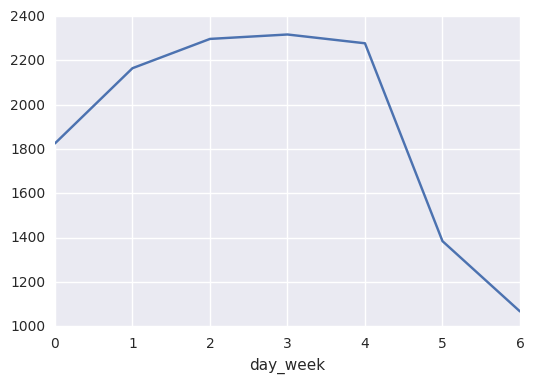

```python
%matplotlib inline
data.plot()
```

#### Quiz: Combining Pandas DataFrames

```python
import pandas as pd

subway_df = pd.DataFrame({
    'UNIT': ['R003', 'R003', 'R003', 'R003', 'R003', 'R004', 'R004', 'R004',
             'R004', 'R004'],
    'DATEn': ['05-01-11', '05-02-11', '05-03-11', '05-04-11', '05-05-11',
              '05-01-11', '05-02-11', '05-03-11', '05-04-11', '05-05-11'],
    'hour': [0, 0, 0, 0, 0, 0, 0, 0, 0, 0],
    'ENTRIESn': [ 4388333,  4388348,  4389885,  4391507,  4393043, 14656120,
                 14656174, 14660126, 14664247, 14668301],
    'EXITSn': [ 2911002,  2911036,  2912127,  2913223,  2914284, 14451774,
               14451851, 14454734, 14457780, 14460818],
    'latitude': [ 40.689945,  40.689945,  40.689945,  40.689945,  40.689945,
                  40.69132 ,  40.69132 ,  40.69132 ,  40.69132 ,  40.69132 ],
    'longitude': [-73.872564, -73.872564, -73.872564, -73.872564, -73.872564,
                  -73.867135, -73.867135, -73.867135, -73.867135, -73.867135]
})

weather_df = pd.DataFrame({
    'DATEn': ['05-01-11', '05-01-11', '05-02-11', '05-02-11', '05-03-11',
              '05-03-11', '05-04-11', '05-04-11', '05-05-11', '05-05-11'],
    'hour': [0, 0, 0, 0, 0, 0, 0, 0, 0, 0],
    'latitude': [ 40.689945,  40.69132 ,  40.689945,  40.69132 ,  40.689945,
                  40.69132 ,  40.689945,  40.69132 ,  40.689945,  40.69132 ],
    'longitude': [-73.872564, -73.867135, -73.872564, -73.867135, -73.872564,
                  -73.867135, -73.872564, -73.867135, -73.872564, -73.867135],
    'pressurei': [ 30.24,  30.24,  30.32,  30.32,  30.14,  30.14,  29.98,  29.98,
                   30.01,  30.01],
    'fog': [0, 0, 0, 0, 0, 0, 0, 0, 0, 0],
    'rain': [0, 0, 0, 0, 0, 0, 0, 0, 0, 0],
    'tempi': [ 52. ,  52. ,  48.9,  48.9,  54. ,  54. ,  57.2,  57.2,  48.9,  48.9],
    'wspdi': [  8.1,   8.1,   6.9,   6.9,   3.5,   3.5,  15. ,  15. ,  15. ,  15. ]
})
```

```python
def combine_dfs(subway_df, weather_df):
    '''
    Fill in this function to take 2 DataFrames, one with subway data and one with weather data,
    and return a single dataframe with one row for each date, hour, and location. Only include
    times and locations that have both subway data and weather data available.
    '''
    merged = subway_df.merge(weather_df,on )
    return None
```

```python
subway_df
```

|  | DATEn | ENTRIESn | EXITSn | UNIT | hour | latitude | longitude |
| --- | --- | --- | --- | --- | --- | --- | --- |
| 0 | 05-01-11 | 4388333 | 2911002 | R003 | 0 | 40.689945 | -73.872564 |
| 1 | 05-02-11 | 4388348 | 2911036 | R003 | 0 | 40.689945 | -73.872564 |
| 2 | 05-03-11 | 4389885 | 2912127 | R003 | 0 | 40.689945 | -73.872564 |
| 3 | 05-04-11 | 4391507 | 2913223 | R003 | 0 | 40.689945 | -73.872564 |
| 4 | 05-05-11 | 4393043 | 2914284 | R003 | 0 | 40.689945 | -73.872564 |
| 5 | 05-01-11 | 14656120 | 14451774 | R004 | 0 | 40.691320 | -73.867135 |
| 6 | 05-02-11 | 14656174 | 14451851 | R004 | 0 | 40.691320 | -73.867135 |
| 7 | 05-03-11 | 14660126 | 14454734 | R004 | 0 | 40.691320 | -73.867135 |
| 8 | 05-04-11 | 14664247 | 14457780 | R004 | 0 | 40.691320 | -73.867135 |
| 9 | 05-05-11 | 14668301 | 14460818 | R004 | 0 | 40.691320 | -73.867135 |

```python
weather_df
```

|  | DATEn | fog | hour | latitude | longitude | pressurei | rain | tempi | wspdi |
| --- | --- | --- | --- | --- | --- | --- | --- | --- | --- |
| 0 | 05-01-11 | 0 | 0 | 40.689945 | -73.872564 | 30.24 | 0 | 52.0 | 8.1 |
| 1 | 05-01-11 | 0 | 0 | 40.691320 | -73.867135 | 30.24 | 0 | 52.0 | 8.1 |
| 2 | 05-02-11 | 0 | 0 | 40.689945 | -73.872564 | 30.32 | 0 | 48.9 | 6.9 |
| 3 | 05-02-11 | 0 | 0 | 40.691320 | -73.867135 | 30.32 | 0 | 48.9 | 6.9 |
| 4 | 05-03-11 | 0 | 0 | 40.689945 | -73.872564 | 30.14 | 0 | 54.0 | 3.5 |
| 5 | 05-03-11 | 0 | 0 | 40.691320 | -73.867135 | 30.14 | 0 | 54.0 | 3.5 |
| 6 | 05-04-11 | 0 | 0 | 40.689945 | -73.872564 | 29.98 | 0 | 57.2 | 15.0 |
| 7 | 05-04-11 | 0 | 0 | 40.691320 | -73.867135 | 29.98 | 0 | 57.2 | 15.0 |
| 8 | 05-05-11 | 0 | 0 | 40.689945 | -73.872564 | 30.01 | 0 | 48.9 | 15.0 |
| 9 | 05-05-11 | 0 | 0 | 40.691320 | -73.867135 | 30.01 | 0 | 48.9 | 15.0 |